# Maps Tutorial

Angel Garcia de la Garza

11/26/2018

```r
library(ggplot2)
library(ggmap)
library(maps)
library(mapdata)
library(tidyverse)
```

## We will use the map_data function to obtain dataframes with the coordinates you need to generate maps.

Check out the maps package to learn more about the different maps it contains!

```r
italy <- map_data("italy")
```

This is what the dataframe looks like:

```r
head(italy)
```

```
##       long      lat group order        region subregion
## 1 11.83295 46.50011     1     1 Bolzano-Bozen      <NA>
## 2 11.81089 46.52784     1     2 Bolzano-Bozen      <NA>
## 3 11.73068 46.51890     1     3 Bolzano-Bozen      <NA>
## 4 11.69115 46.52257     1     4 Bolzano-Bozen      <NA>
## 5 11.65041 46.50721     1     5 Bolzano-Bozen      <NA>
## 6 11.63282 46.48045     1     6 Bolzano-Bozen      <NA>
```

We use geom_polygon to create the different shapes. You use the fixed coordinates function to fix the aspect ratio.

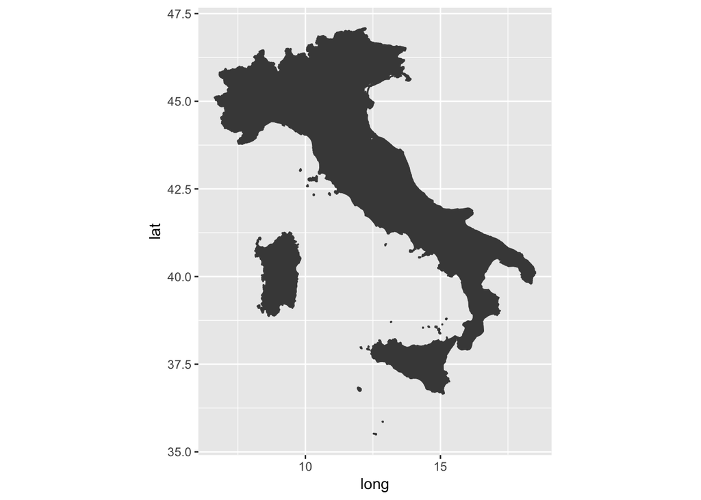

```r
ggplot() + geom_polygon(data = italy,
                        aes(x=long, y = lat, group = group),
                        color = "gray28", fill="gray28") +
           coord_fixed(1.3)
```

This looks bad with this ratio

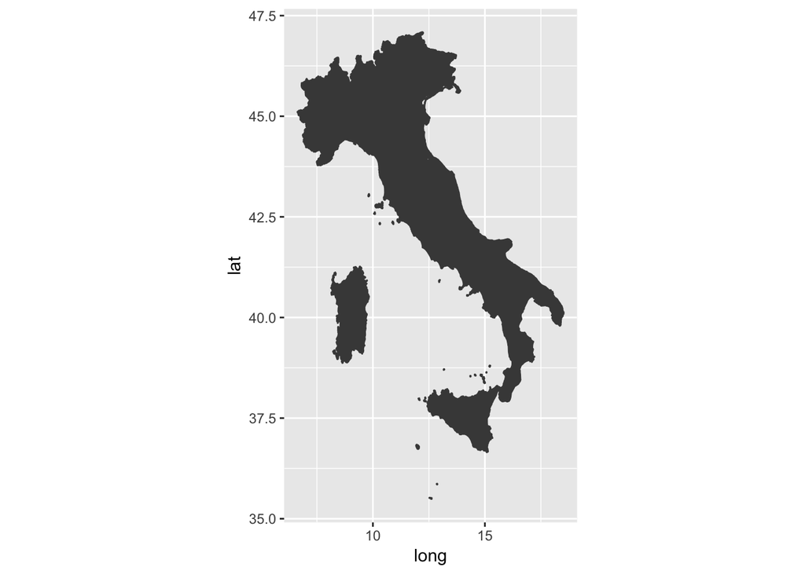

```r
ggplot() + geom_polygon(data = italy,
                        aes(x=long, y = lat, group = group),
                        color = "gray28", fill="gray28") +
           coord_fixed(1.8)
```

In the above, I forced the color so that you couldn’t tell the regions apart, you can change this.

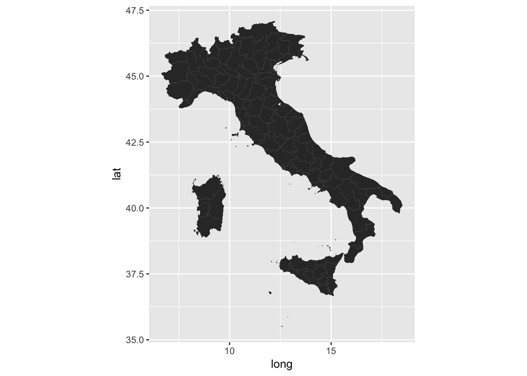

```r
ggplot() + geom_polygon(data = italy,
                        aes(x=long, y = lat, group = group)) +
           coord_fixed(1.3)
```

You need to have the group variable so that each polygon is drawn properly. Otherwise the lines get mixed up.

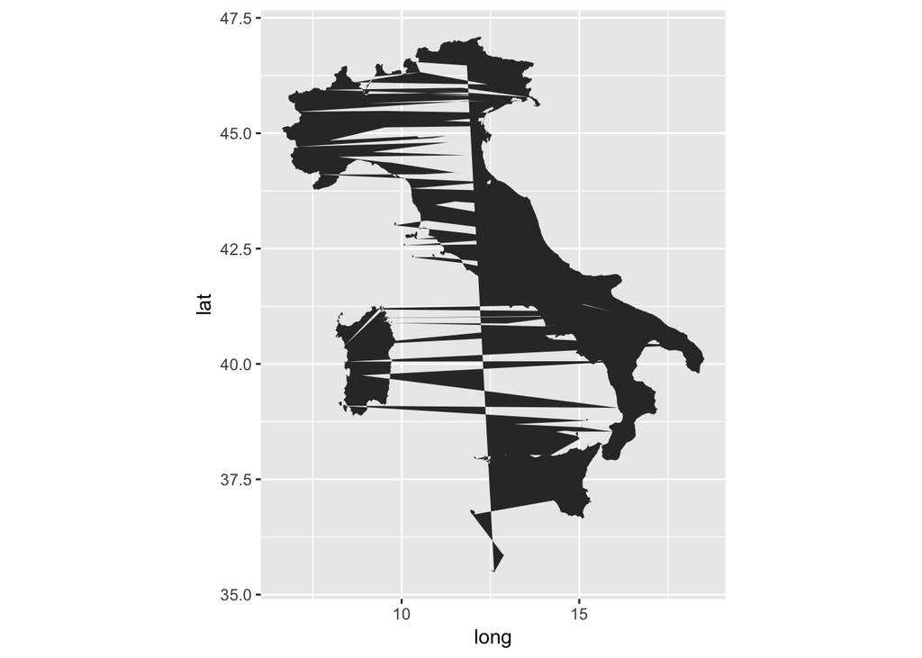

```r
ggplot() + geom_polygon(data = italy,
                        aes(x=long, y = lat)) +
           coord_fixed(1.3)
```

You can play with the aesthetics

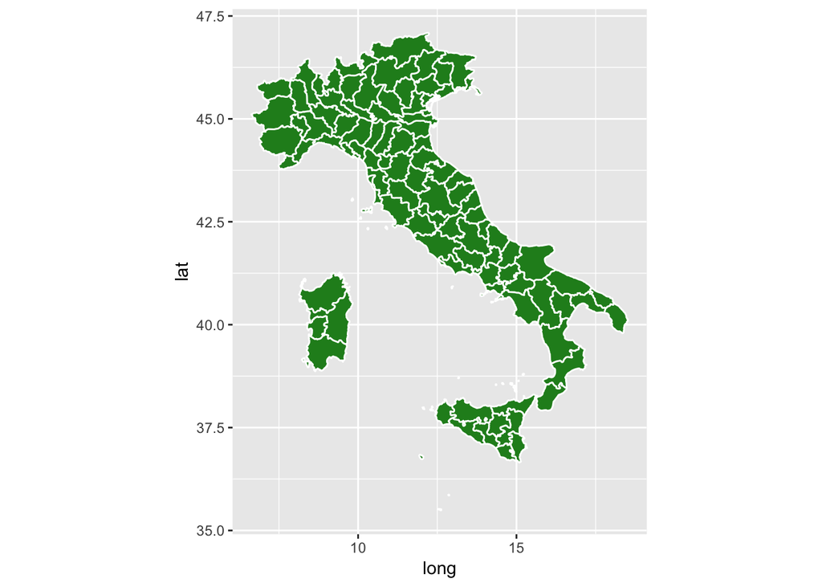

```r
ggplot() +
  geom_polygon(data = italy, aes(x=long, y = lat, group = group), fill = "forestgreen", color = "white") +
  coord_fixed(1.3)
```

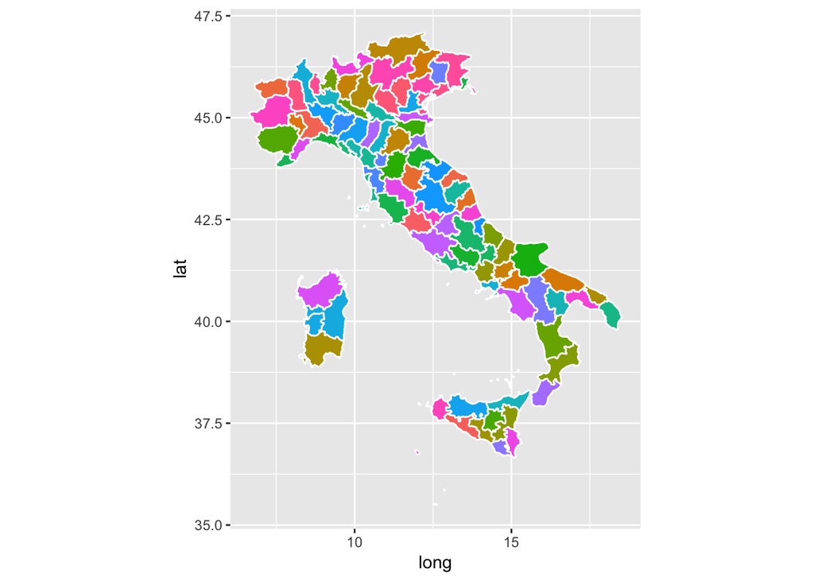

```r
ggplot() +
  geom_polygon(data = italy, aes(x=long, y = lat, group = group, fill=region),
               color = "white") +
  coord_fixed(1.3) +
  guides(fill=FALSE)
```

## You can add points to the plot

```r
italian_cities <- rbind(c(43.769562, 11.255814, "Florence"),
                         c(41.902782, 12.496366, "Rome"),
                         c(45.438759, 12.327145, "Venice")
                         ) %>%
                   as.tibble() %>%
                   mutate(lat = as.numeric(V1),
                          long = as.numeric(V2),
                          names = V3) %>%
                   select(long,lat,names)
```

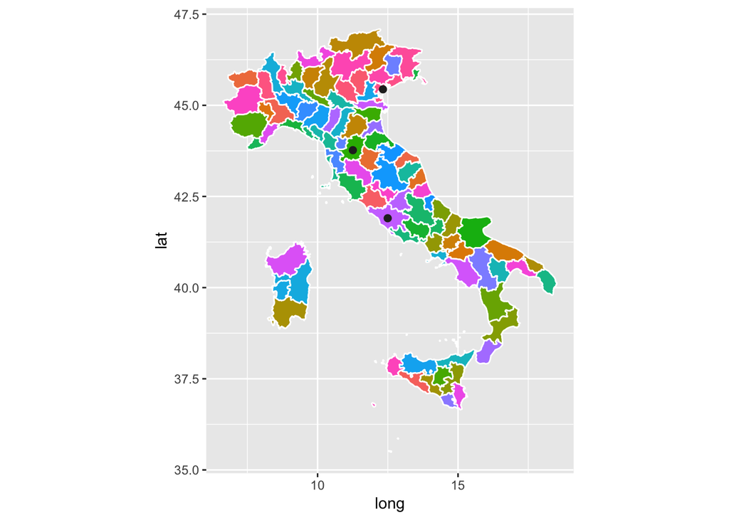

```r
ggplot() +
  geom_polygon(data = italy, aes(x=long, y = lat, group = group, fill=region),
               color = "white") +
  coord_fixed(1.3) +
  guides(fill=FALSE) +
  geom_point(data = italian_cities, aes(x = long, y = lat), color = "grey15", size = 2)
```

## You can even anotate the plot

This one uses the label function

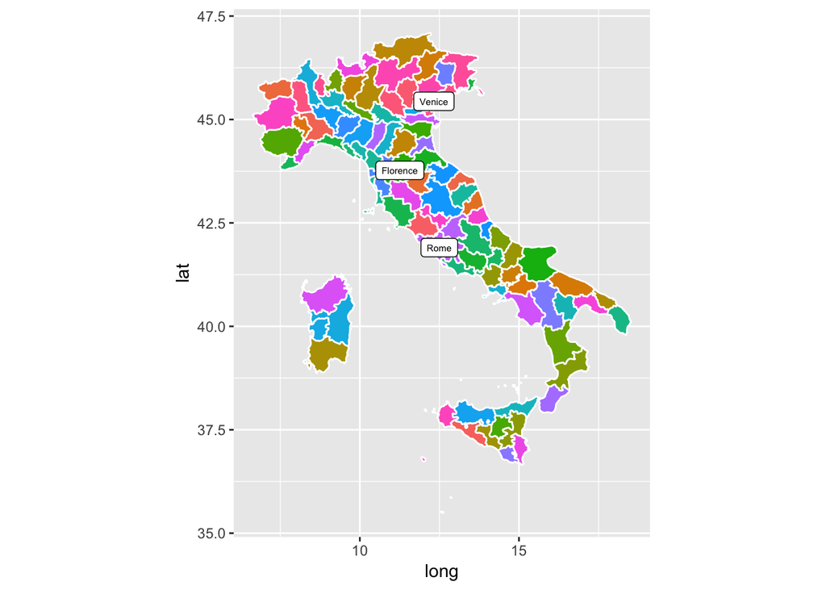

```r
ggplot() +
  geom_polygon(data = italy, aes(x=long, y = lat, group = group, fill=region),
               color = "white") +
  coord_fixed(1.3) +
  guides(fill=FALSE) +
  geom_label(data = italian_cities, aes(x = long, y = lat, label = names),
             size = 2)
```

This one uses the text function

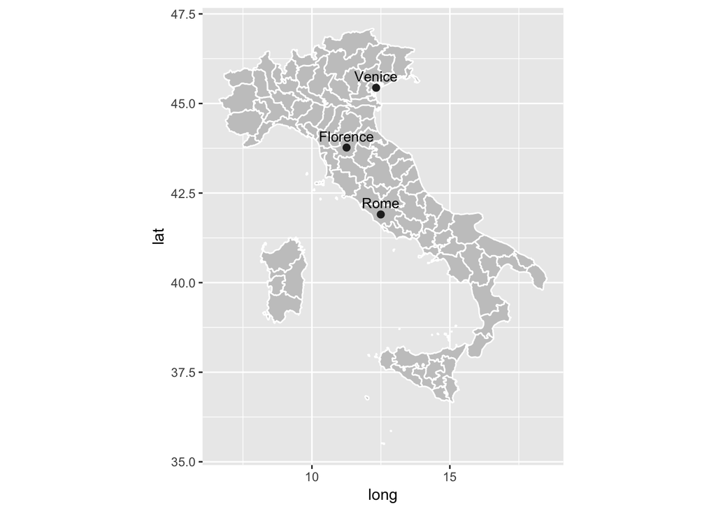

```r
ggplot() +
  geom_polygon(data = italy, aes(x=long, y = lat, group = group),
               color = "white", fill = "gray78") +
  coord_fixed(1.3) +
  guides(fill=FALSE) +
  geom_point(data = italian_cities, aes(x = long, y = lat),
             color = "grey15", size = 2) +
  geom_text(data = italian_cities, aes(x = long, y = lat + 0.32, label = names),
             size = 3.5)
```

## You can also color by other variables, such as population density.

### The code below does some cleaning to get the two datasets to align

```r
italian_cities_density <- read_csv("~/Desktop/provinces_italy.csv") %>%
                            rename(subregion = Province)
other.regions <- c("Agrigento","Trapani","Messina","Palermo",
                   "Caltanissetta", "Udine","Pordenone","Gorizia", "Venezia",
                   "Trieste",  "Milano",   "Padova",   "Torino",  "Mantova",
                   "Genova",   "Massa-Carrara", "Forli'", "Firenze",
                   "Pesaro e Urbino", "Arezzo",
                   "Livorno", "Grosseto", "Sassari",
                   "Avellino", "Latina",  "Napoli", "Cagliari")

italy <- italy %>%
            mutate(subregion = ifelse(is.na(subregion),
                                            region,
                                            subregion),
                   subregion = ifelse(region %in% other.regions,
                                      region,
                                      subregion)) %>%
            left_join(italian_cities_density, "subregion")
```

## This plot is colored by region population density

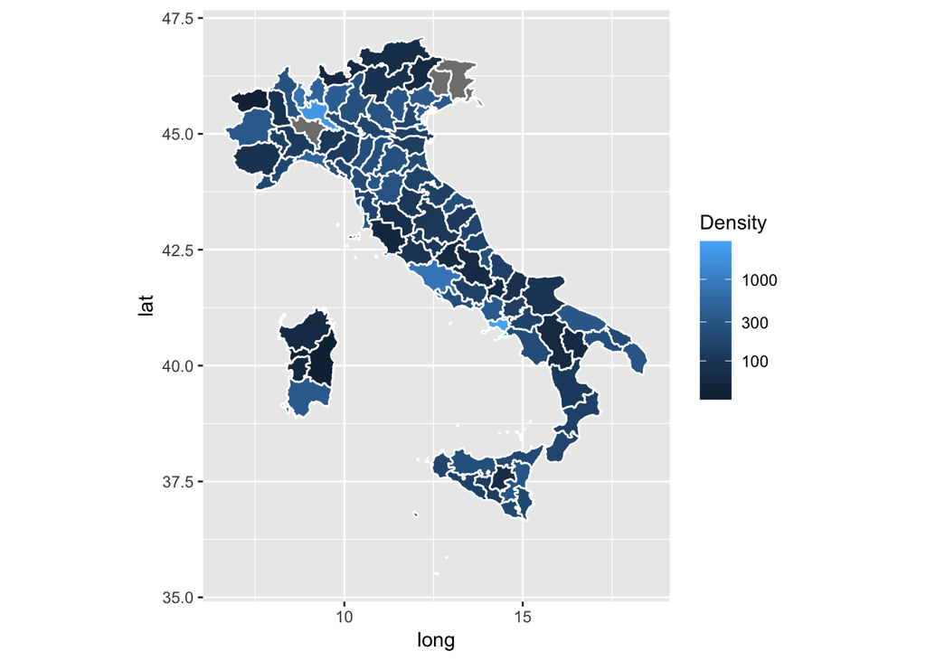

```r
ggplot() +
  geom_polygon(data = italy, aes(x=long, y = lat, group = group, fill=Density),
               color = "white") +
  coord_fixed(1.3) +
  scale_fill_gradient(trans = "log10")
```

## This plot is colored using the administrative regions.

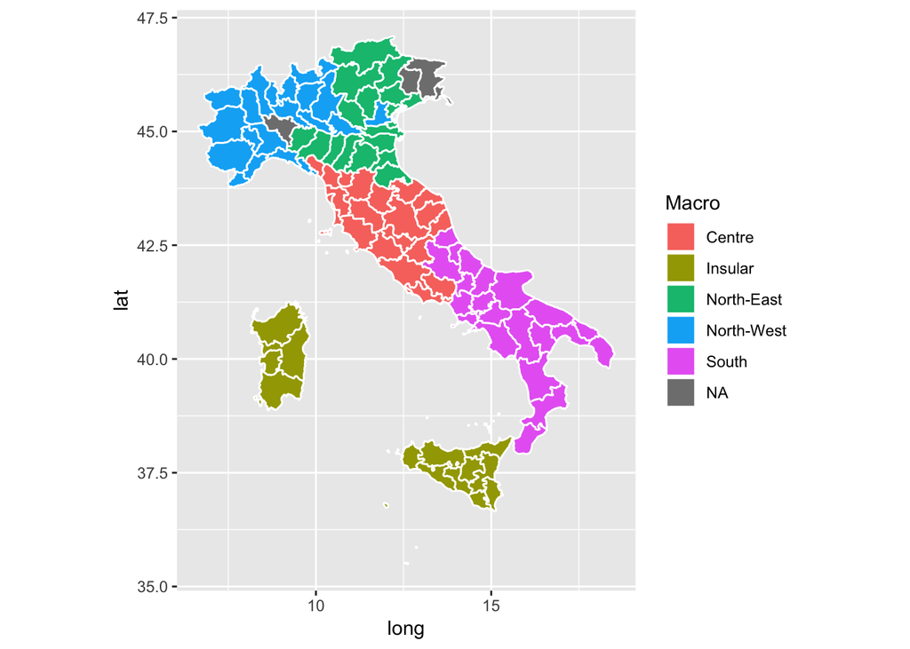

```r
ggplot() +
  geom_polygon(data = italy, aes(x=long, y = lat, group = group, fill = Macro),
               color = "white") +
  coord_fixed(1.3)
```

## You can zoom in like this:

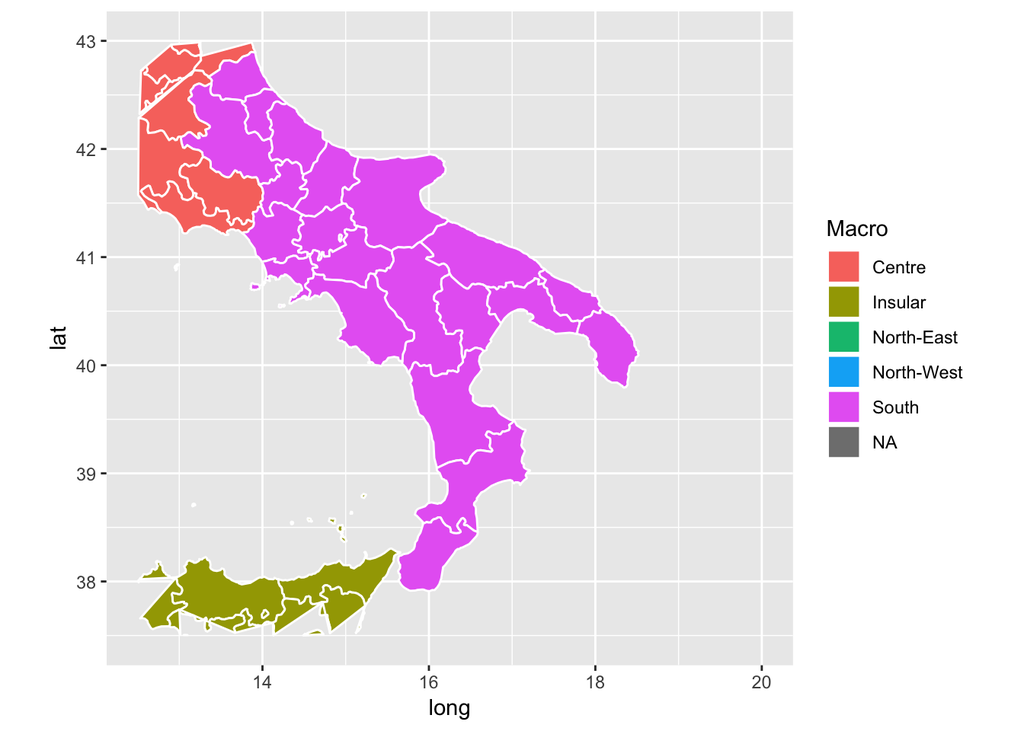

```r
ggplot() +
  geom_polygon(data = italy, aes(x=long, y = lat, group = group, fill = Macro),
               color = "white") +
  coord_fixed(1.3) +
  xlim(12.5,20) + ylim(37.5, 43)
```

Or alternatively:

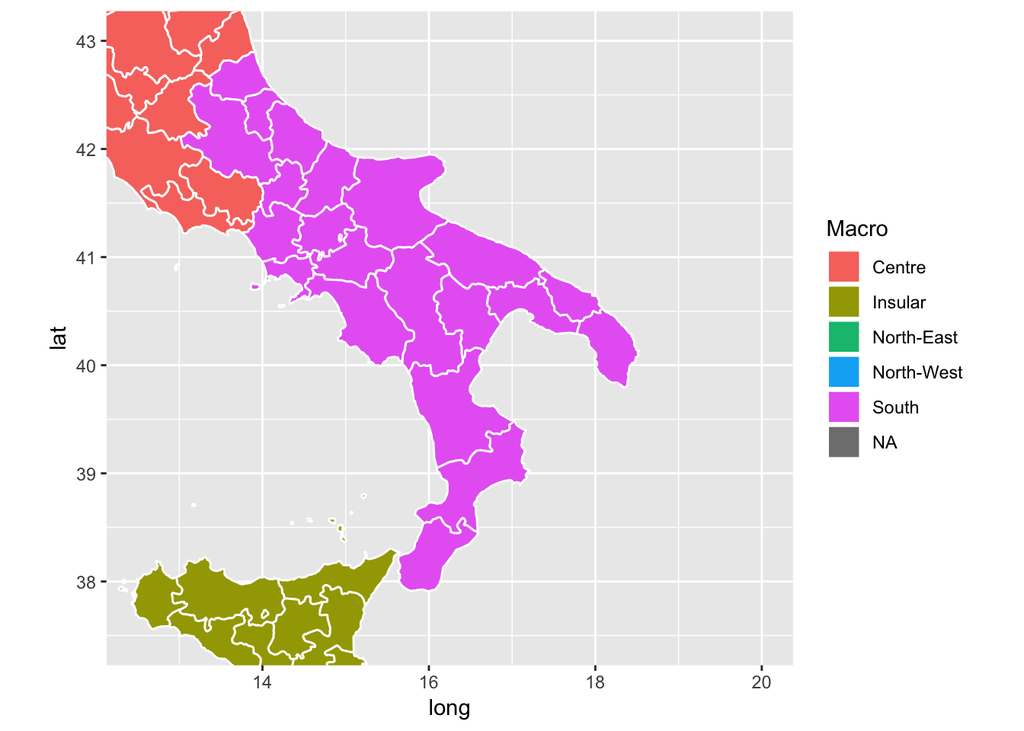

```r
ggplot() +
  geom_polygon(data = italy, aes(x=long, y = lat, group = group, fill = Macro),
               color = "white") +
  coord_fixed(xlim = c(12.5,20),  ylim = c(37.5, 43), ratio = 1.3)
```

## Additional aesthetic changes

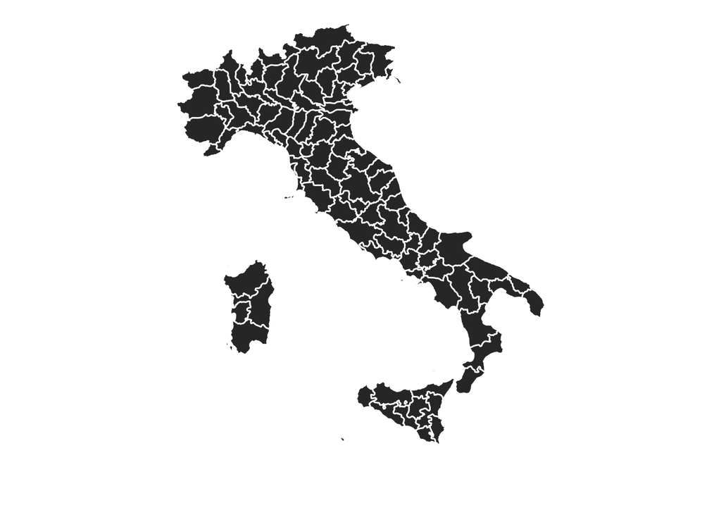

```r
ggplot() +
  geom_polygon(data = italy, aes(x=long, y = lat, group = group),
               color = "white") +
 coord_fixed(1.3) +
 theme_nothing()
```

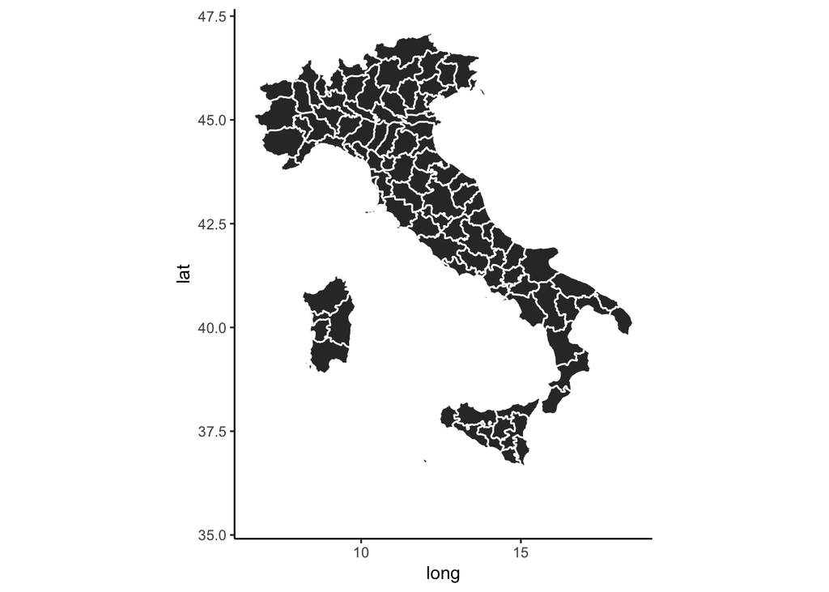

```r
ggplot() +
  geom_polygon(data = italy, aes(x=long, y = lat, group = group),
               color = "white") +
 coord_fixed(1.3) +
 theme_classic()
```

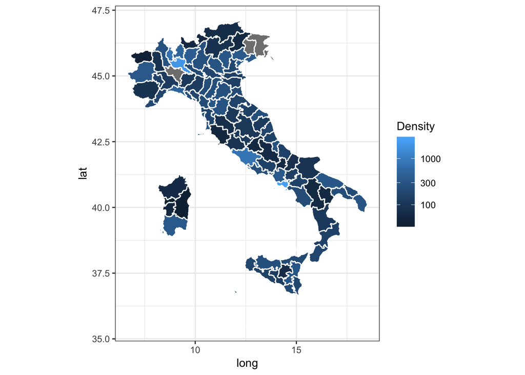

```r
ggplot() +
  geom_polygon(data = italy, aes(x=long, y = lat, group = group, fill = Density),
               color = "white") +
 coord_fixed(1.3) +
 scale_fill_gradient(trans = "log10") +
 theme_bw()
```